# Navigating the Fast Lane: A Case Study on Bike-Share’s Speedy Success

Devi Nirfana H

2023-11-23

This analysis is for case study 1 from the Google Data Analytics Certificate (Cyclistic). It’s originally based on the case study “‘Sophisticated, Clear, and Polished’: Divvy and Data Visualization” written by Kevin Hartman(found here: https://artscience.blog/home/divvy-dataviz-case-study).

# Data Source and Limitations

[Download the Cyclistic trip data here.](https://divvy-tripdata.s3.amazonaws.com/index.html) The data has been made available by Motivate International Inc. under this [license](https://www.divvybikes.com/data-license-agreement).

The data does not include personally identifiable information (PII) about riders. This means that it is not possible to connect pass purchases to credit card numbers or to determine if casual riders live in the Cyclistic service area or if they have purchased multiple single passes. This limitation may impact the ability to make certain inferences about user behavior and preferences.

# Scenario

Cyclistic, a bike-share company in Chicago, aims to convert casual riders into annual members. Their marketing analyst team plans to analyze historical bike trip data to identify trends and develop targeted marketing campaigns to appeal to casual riders’ needs.

As a junior data analyst, my focus is on unraveling the distinctive usage patterns between casual riders and annual members. The director of marketing emphasizes that the future success of Cyclistic hinges on maximizing annual memberships. In response to this directive, my team is diligently studying data to discern how these two user groups interact with Cyclistic bikes differently.

Our ultimate goal is to craft a targeted marketing strategy aimed at converting casual riders into committed annual members. However, before presenting our recommendations to Cyclistic executives, we understand the importance of substantiating our proposals with compelling data insights and professional visualizations.

I chose R for analyzing bike-share data due to its powerful statistical capabilities, extensive data manipulation tools, and rich ecosystem of data visualization packages.

# Import Data and Package Setup

```r
library(tidyverse)
```

```r
library(ggplot2)
library(lubridate)
```

```r
setwd("~/Documents/GitHub/R-project")

q1_2019 <- read_csv("./data/Divvy_Trips_2019_Q1.csv")
q2_2019 <- read_csv("./data/Divvy_Trips_2019_Q2.csv")
q3_2019 <- read_csv("./data/Divvy_Trips_2019_Q3.csv")
q4_2019 <- read_csv("./data/Divvy_Trips_2019_Q4.csv")
```

# Combining data into a single file

Before the data be combine, we have to identifying matching column names to facilitate data combination process.

```r
colnames(q1_2019)
```

```
##  [1] "trip_id"           "start_time"        "end_time"
##  [4] "bikeid"            "tripduration"      "from_station_id"
##  [7] "from_station_name" "to_station_id"     "to_station_name"
## [10] "usertype"          "gender"            "birthyear"
```

```r
colnames(q2_2019)
```

```
##  [1] "01 - Rental Details Rental ID"
##  [2] "01 - Rental Details Local Start Time"
##  [3] "01 - Rental Details Local End Time"
##  [4] "01 - Rental Details Bike ID"
##  [5] "01 - Rental Details Duration In Seconds Uncapped"
##  [6] "03 - Rental Start Station ID"
##  [7] "03 - Rental Start Station Name"
##  [8] "02 - Rental End Station ID"
##  [9] "02 - Rental End Station Name"
## [10] "User Type"
## [11] "Member Gender"
## [12] "05 - Member Details Member Birthday Year"
```

```r
colnames(q3_2019)
```

```
##  [1] "trip_id"           "start_time"        "end_time"
##  [4] "bikeid"            "tripduration"      "from_station_id"
##  [7] "from_station_name" "to_station_id"     "to_station_name"
## [10] "usertype"          "gender"            "birthyear"
```

```r
colnames(q4_2019)
```

```
##  [1] "trip_id"           "start_time"        "end_time"
##  [4] "bikeid"            "tripduration"      "from_station_id"
##  [7] "from_station_name" "to_station_id"     "to_station_name"
## [10] "usertype"          "gender"            "birthyear"
```

Due to inconsistencies in column names and numbers, particularly in the Q2 2019 data, the column names will be standardized.

```r
q1_2019 <- rename(q1_2019,
                  ride_id = trip_id,
                  bike_id = bikeid,
                  started_at = start_time,
                  ended_at = end_time,
                  start_station_name = from_station_name,
                  start_station_id = from_station_id,
                  end_station_name = to_station_name,
                  end_station_id = to_station_id,
                  member_casual = usertype)
```

```r
q2_2019 <- rename(q2_2019,
                   ride_id = "01 - Rental Details Rental ID",
                   bike_id = "01 - Rental Details Bike ID",
                   started_at = "01 - Rental Details Local Start Time",
                   ended_at = "01 - Rental Details Local End Time",
                   start_station_name = "03 - Rental Start Station Name",
                   start_station_id = "03 - Rental Start Station ID",
                   end_station_name = "02 - Rental End Station Name",
                   end_station_id = "02 - Rental End Station ID",
                   member_casual = "User Type")
```

```r
q3_2019 <- rename(q3_2019,
                   ride_id = trip_id,
                   bike_id = bikeid,
                   started_at = start_time,
                   ended_at = end_time,
                   start_station_name = from_station_name,
                   start_station_id = from_station_id,
                   end_station_name = to_station_name,
                   end_station_id = to_station_id,
                   member_casual = usertype)
```

```r
q4_2019 <- rename(q4_2019,
                   ride_id = trip_id,
                   bike_id = bikeid,
                   started_at = start_time,
                   ended_at = end_time,
                   start_station_name = from_station_name,
                   start_station_id = from_station_id,
                   end_station_name = to_station_name,
                   end_station_id = to_station_id,
                   member_casual = usertype)
```

After Renaming the data then we review the datasets to uncover any discrepancies.

```r
str(q1_2019)
```

```
## spc_tbl_ [365,069 × 12] (S3: spec_tbl_df/tbl_df/tbl/data.frame)
##  $ ride_id           : num [1:365069] 21742443 21742444 21742445 21742446 21742447 ...
##  $ started_at        : POSIXct[1:365069], format: "2019-01-01 00:04:37" "2019-01-01 00:08:13" ...
##  $ ended_at          : POSIXct[1:365069], format: "2019-01-01 00:11:07" "2019-01-01 00:15:34" ...
##  $ bike_id           : num [1:365069] 2167 4386 1524 252 1170 ...
##  $ tripduration      : num [1:365069] 390 441 829 1783 364 ...
##  $ start_station_id  : num [1:365069] 199 44 15 123 173 98 98 211 150 268 ...
##  $ start_station_name: chr [1:365069] "Wabash Ave & Grand Ave" "State St & Randolph St" "Racine Ave & 18th St" "California Ave & Milwaukee Ave" ...
##  $ end_station_id    : num [1:365069] 84 624 644 176 35 49 49 142 148 141 ...
##  $ end_station_name  : chr [1:365069] "Milwaukee Ave & Grand Ave" "Dearborn St & Van Buren St (*)" "Western Ave & Fillmore St (*)" "Clark St & Elm St" ...
##  $ member_casual     : chr [1:365069] "Subscriber" "Subscriber" "Subscriber" "Subscriber" ...
##  $ gender            : chr [1:365069] "Male" "Female" "Female" "Male" ...
##  $ birthyear         : num [1:365069] 1989 1990 1994 1993 1994 ...
##  - attr(*, "spec")=
##   .. cols(
##   ..   trip_id = col_double(),
##   ..   start_time = col_datetime(format = ""),
##   ..   end_time = col_datetime(format = ""),
##   ..   bikeid = col_double(),
##   ..   tripduration = col_number(),
##   ..   from_station_id = col_double(),
##   ..   from_station_name = col_character(),
##   ..   to_station_id = col_double(),
##   ..   to_station_name = col_character(),
##   ..   usertype = col_character(),
##   ..   gender = col_character(),
##   ..   birthyear = col_double()
##   .. )
##  - attr(*, "problems")=<externalptr>
```

```r
str(q2_2019)
```

```
## spc_tbl_ [1,108,163 × 12] (S3: spec_tbl_df/tbl_df/tbl/data.frame)
##  $ ride_id                                         : num [1:1108163] 22178529 22178530 22178531 22178532 22178533 ...
##  $ started_at                                      : POSIXct[1:1108163], format: "2019-04-01 00:02:22" "2019-04-01 00:03:02" ...
##  $ ended_at                                        : POSIXct[1:1108163], format: "2019-04-01 00:09:48" "2019-04-01 00:20:30" ...
##  $ bike_id                                         : num [1:1108163] 6251 6226 5649 4151 3270 ...
##  $ 01 - Rental Details Duration In Seconds Uncapped: num [1:1108163] 446 1048 252 357 1007 ...
##  $ start_station_id                                : num [1:1108163] 81 317 283 26 202 420 503 260 211 211 ...
##  $ start_station_name                              : chr [1:1108163] "Daley Center Plaza" "Wood St & Taylor St" "LaSalle St & Jackson Blvd" "McClurg Ct & Illinois St" ...
##  $ end_station_id                                  : num [1:1108163] 56 59 174 133 129 426 500 499 211 211 ...
##  $ end_station_name                                : chr [1:1108163] "Desplaines St & Kinzie St" "Wabash Ave & Roosevelt Rd" "Canal St & Madison St" "Kingsbury St & Kinzie St" ...
##  $ member_casual                                   : chr [1:1108163] "Subscriber" "Subscriber" "Subscriber" "Subscriber" ...
##  $ Member Gender                                   : chr [1:1108163] "Male" "Female" "Male" "Male" ...
##  $ 05 - Member Details Member Birthday Year        : num [1:1108163] 1975 1984 1990 1993 1992 ...
##  - attr(*, "spec")=
##   .. cols(
##   ..   `01 - Rental Details Rental ID` = col_double(),
##   ..   `01 - Rental Details Local Start Time` = col_datetime(format = ""),
##   ..   `01 - Rental Details Local End Time` = col_datetime(format = ""),
##   ..   `01 - Rental Details Bike ID` = col_double(),
##   ..   `01 - Rental Details Duration In Seconds Uncapped` = col_number(),
##   ..   `03 - Rental Start Station ID` = col_double(),
##   ..   `03 - Rental Start Station Name` = col_character(),
##   ..   `02 - Rental End Station ID` = col_double(),
##   ..   `02 - Rental End Station Name` = col_character(),
##   ..   `User Type` = col_character(),
##   ..   `Member Gender` = col_character(),
##   ..   `05 - Member Details Member Birthday Year` = col_double()
##   .. )
##  - attr(*, "problems")=<externalptr>
```

```r
str(q3_2019)
```

```
## spc_tbl_ [1,640,718 × 12] (S3: spec_tbl_df/tbl_df/tbl/data.frame)
##  $ ride_id           : num [1:1640718] 23479388 23479389 23479390 23479391 23479392 ...
##  $ started_at        : POSIXct[1:1640718], format: "2019-07-01 00:00:27" "2019-07-01 00:01:16" ...
##  $ ended_at          : POSIXct[1:1640718], format: "2019-07-01 00:20:41" "2019-07-01 00:18:44" ...
##  $ bike_id           : num [1:1640718] 3591 5353 6180 5540 6014 ...
##  $ tripduration      : num [1:1640718] 1214 1048 1554 1503 1213 ...
##  $ start_station_id  : num [1:1640718] 117 381 313 313 168 300 168 313 43 43 ...
##  $ start_station_name: chr [1:1640718] "Wilton Ave & Belmont Ave" "Western Ave & Monroe St" "Lakeview Ave & Fullerton Pkwy" "Lakeview Ave & Fullerton Pkwy" ...
##  $ end_station_id    : num [1:1640718] 497 203 144 144 62 232 62 144 195 195 ...
##  $ end_station_name  : chr [1:1640718] "Kimball Ave & Belmont Ave" "Western Ave & 21st St" "Larrabee St & Webster Ave" "Larrabee St & Webster Ave" ...
##  $ member_casual     : chr [1:1640718] "Subscriber" "Customer" "Customer" "Customer" ...
##  $ gender            : chr [1:1640718] "Male" NA NA NA ...
##  $ birthyear         : num [1:1640718] 1992 NA NA NA NA ...
##  - attr(*, "spec")=
##   .. cols(
##   ..   trip_id = col_double(),
##   ..   start_time = col_datetime(format = ""),
##   ..   end_time = col_datetime(format = ""),
##   ..   bikeid = col_double(),
##   ..   tripduration = col_number(),
##   ..   from_station_id = col_double(),
##   ..   from_station_name = col_character(),
##   ..   to_station_id = col_double(),
##   ..   to_station_name = col_character(),
##   ..   usertype = col_character(),
##   ..   gender = col_character(),
##   ..   birthyear = col_double()
##   .. )
##  - attr(*, "problems")=<externalptr>
```

```r
str(q4_2019)
```

```
## spc_tbl_ [704,054 × 12] (S3: spec_tbl_df/tbl_df/tbl/data.frame)
##  $ ride_id           : num [1:704054] 25223640 25223641 25223642 25223643 25223644 ...
##  $ started_at        : POSIXct[1:704054], format: "2019-10-01 00:01:39" "2019-10-01 00:02:16" ...
##  $ ended_at          : POSIXct[1:704054], format: "2019-10-01 00:17:20" "2019-10-01 00:06:34" ...
##  $ bike_id           : num [1:704054] 2215 6328 3003 3275 5294 ...
##  $ tripduration      : num [1:704054] 940 258 850 2350 1867 ...
##  $ start_station_id  : num [1:704054] 20 19 84 313 210 156 84 156 156 336 ...
##  $ start_station_name: chr [1:704054] "Sheffield Ave & Kingsbury St" "Throop (Loomis) St & Taylor St" "Milwaukee Ave & Grand Ave" "Lakeview Ave & Fullerton Pkwy" ...
##  $ end_station_id    : num [1:704054] 309 241 199 290 382 226 142 463 463 336 ...
##  $ end_station_name  : chr [1:704054] "Leavitt St & Armitage Ave" "Morgan St & Polk St" "Wabash Ave & Grand Ave" "Kedzie Ave & Palmer Ct" ...
##  $ member_casual     : chr [1:704054] "Subscriber" "Subscriber" "Subscriber" "Subscriber" ...
##  $ gender            : chr [1:704054] "Male" "Male" "Female" "Male" ...
##  $ birthyear         : num [1:704054] 1987 1998 1991 1990 1987 ...
##  - attr(*, "spec")=
##   .. cols(
##   ..   trip_id = col_double(),
##   ..   start_time = col_datetime(format = ""),
##   ..   end_time = col_datetime(format = ""),
##   ..   bikeid = col_double(),
##   ..   tripduration = col_number(),
##   ..   from_station_id = col_double(),
##   ..   from_station_name = col_character(),
##   ..   to_station_id = col_double(),
##   ..   to_station_name = col_character(),
##   ..   usertype = col_character(),
##   ..   gender = col_character(),
##   ..   birthyear = col_double()
##   .. )
##  - attr(*, "problems")=<externalptr>
```

## changing data type

Apparently `ride_id` and `bike_id` was detected as numerical data type so we have to convert into character for ensure proper data stacking.

```r
q1_2019 <-  mutate(q1_2019, ride_id = as.character(ride_id),
                   bike_id = as.character(bike_id))
```

```r
q2_2019 <-  mutate(q2_2019, ride_id = as.character(ride_id),
                   bike_id = as.character(bike_id))
```

```r
q3_2019 <-  mutate(q3_2019, ride_id = as.character(ride_id),
                   bike_id = as.character(bike_id))
```

```r
q4_2019 <-  mutate(q4_2019, ride_id = as.character(ride_id),
                   bike_id = as.character(bike_id))
```

## Combining data into one big data frame.

```r
all_trips <- bind_rows(q1_2019, q2_2019, q3_2019, q4_2019)
```

```r
colnames(all_trips)
```

```
##  [1] "ride_id"
##  [2] "started_at"
##  [3] "ended_at"
##  [4] "bike_id"
##  [5] "tripduration"
##  [6] "start_station_id"
##  [7] "start_station_name"
##  [8] "end_station_id"
##  [9] "end_station_name"
## [10] "member_casual"
## [11] "gender"
## [12] "birthyear"
## [13] "01 - Rental Details Duration In Seconds Uncapped"
## [14] "Member Gender"
## [15] "05 - Member Details Member Birthday Year"
```

The `birthyear` and `gender` will be removed from the dataset. The main focus was to find pattern and broader trends and insights related to bike sharing without compromising individual privacy.

The duration or `tripduration` column will recalculated later.

```r
all_trips <- all_trips %>%
  select(c(ride_id,
           started_at,
           ended_at,
           bike_id,
           start_station_name,
           start_station_id,
           end_station_name,
           end_station_id,
           member_casual))
```

Since in this analysis we used member for subscriber and casual for a regular customer we will name the value inside the `member_casual` columns to be “Casual” for “Customer” and “Member” for “Subscriber”.

```r
all_trips <-  all_trips %>%
  mutate(member_casual = recode(member_casual
                                ,"Subscriber" = "Member"
                                ,"Customer" = "Casual"))
```

# Clean Up and Prepare data for analysis

Inspecting the new table that has been created.

```r
colnames(all_trips)
```

```
## [1] "ride_id"            "started_at"         "ended_at"
## [4] "bike_id"            "start_station_name" "start_station_id"
## [7] "end_station_name"   "end_station_id"     "member_casual"
```

```r
dim(all_trips)
```

```
## [1] 3818004       9
```

```r
head(all_trips)  # See the first 6 rows of data frame.
```

```
## # A tibble: 6 × 9
##   ride_id  started_at          ended_at            bike_id start_station_name
##   <chr>    <dttm>              <dttm>              <chr>   <chr>
## 1 21742443 2019-01-01 00:04:37 2019-01-01 00:11:07 2167    Wabash Ave & Grand A…
## 2 21742444 2019-01-01 00:08:13 2019-01-01 00:15:34 4386    State St & Randolph …
## 3 21742445 2019-01-01 00:13:23 2019-01-01 00:27:12 1524    Racine Ave & 18th St
## 4 21742446 2019-01-01 00:13:45 2019-01-01 00:43:28 252     California Ave & Mil…
## 5 21742447 2019-01-01 00:14:52 2019-01-01 00:20:56 1170    Mies van der Rohe Wa…
## 6 21742448 2019-01-01 00:15:33 2019-01-01 00:19:09 2437    LaSalle St & Washing…
## # ℹ 4 more variables: start_station_id <dbl>, end_station_name <chr>,
## #   end_station_id <dbl>, member_casual <chr>
```

```r
tail(all_trips) # See the last 6 rows of data frame.
```

```
## # A tibble: 6 × 9
##   ride_id  started_at          ended_at            bike_id start_station_name
##   <chr>    <dttm>              <dttm>              <chr>   <chr>
## 1 25962899 2019-12-31 23:54:54 2020-01-01 00:22:02 5996    Mies van der Rohe Wa…
## 2 25962900 2019-12-31 23:56:13 2020-01-01 00:15:45 2196    Green St & Randolph …
## 3 25962901 2019-12-31 23:56:34 2020-01-01 00:22:08 4877    Millennium Park
## 4 25962902 2019-12-31 23:57:05 2020-01-01 00:05:46 863     Michigan Ave & 8th St
## 5 25962903 2019-12-31 23:57:11 2020-01-01 00:05:45 2637    Michigan Ave & 8th St
## 6 25962904 2019-12-31 23:57:17 2019-12-31 23:59:18 5930    Broadway & Sheridan …
## # ℹ 4 more variables: start_station_id <dbl>, end_station_name <chr>,
## #   end_station_id <dbl>, member_casual <chr>
```

Examining the first and last six rows using the ‘head’ and ‘tail’ functions, respectively, reveals the structure and content of the data.

```r
str(all_trips)  #See list of columns and data types (numeric, character, etc)
```

```
## tibble [3,818,004 × 9] (S3: tbl_df/tbl/data.frame)
##  $ ride_id           : chr [1:3818004] "21742443" "21742444" "21742445" "21742446" ...
##  $ started_at        : POSIXct[1:3818004], format: "2019-01-01 00:04:37" "2019-01-01 00:08:13" ...
##  $ ended_at          : POSIXct[1:3818004], format: "2019-01-01 00:11:07" "2019-01-01 00:15:34" ...
##  $ bike_id           : chr [1:3818004] "2167" "4386" "1524" "252" ...
##  $ start_station_name: chr [1:3818004] "Wabash Ave & Grand Ave" "State St & Randolph St" "Racine Ave & 18th St" "California Ave & Milwaukee Ave" ...
##  $ start_station_id  : num [1:3818004] 199 44 15 123 173 98 98 211 150 268 ...
##  $ end_station_name  : chr [1:3818004] "Milwaukee Ave & Grand Ave" "Dearborn St & Van Buren St (*)" "Western Ave & Fillmore St (*)" "Clark St & Elm St" ...
##  $ end_station_id    : num [1:3818004] 84 624 644 176 35 49 49 142 148 141 ...
##  $ member_casual     : chr [1:3818004] "Member" "Member" "Member" "Member" ...
```

```r
summary(all_trips)  #Statistical summary of data. Mainly for numerics
```

```
##    ride_id            started_at
##  Length:3818004     Min.   :2019-01-01 00:04:37.00
##  Class :character   1st Qu.:2019-05-29 15:49:26.50
##  Mode  :character   Median :2019-07-25 17:50:54.00
##                     Mean   :2019-07-19 21:47:37.11
##                     3rd Qu.:2019-09-15 06:48:05.75
##                     Max.   :2019-12-31 23:57:17.00
##     ended_at                        bike_id          start_station_name
##  Min.   :2019-01-01 00:11:07.00   Length:3818004     Length:3818004
##  1st Qu.:2019-05-29 16:09:28.25   Class :character   Class :character
##  Median :2019-07-25 18:12:23.00   Mode  :character   Mode  :character
##  Mean   :2019-07-19 22:11:47.56
##  3rd Qu.:2019-09-15 08:30:13.25
##  Max.   :2020-01-21 13:54:35.00
##  start_station_id end_station_name   end_station_id  member_casual
##  Min.   :  1.0    Length:3818004     Min.   :  1.0   Length:3818004
##  1st Qu.: 77.0    Class :character   1st Qu.: 77.0   Class :character
##  Median :174.0    Mode  :character   Median :174.0   Mode  :character
##  Mean   :201.7                       Mean   :202.6
##  3rd Qu.:289.0                       3rd Qu.:291.0
##  Max.   :673.0                       Max.   :673.0
```

## Add more columns

Currently, the data is only available at the individual ride level, which limits the scope of aggregation and analysis. To expand the possibilities for data aggregation and gain a broader understanding of usage patterns, it is necessary to introduce additional columns containing information like day, month, and year. These additional columns will provide a temporal context for the ride data, enabling aggregation and analysis based on daily, monthly, or yearly trends.

```r
# Add columns that list the date, month, day, and year of each ride
# This will allow us to aggregate ride data for each month, day, or year
# before completing these operations we could only aggregate at the ride level

all_trips$date <- as.Date(all_trips$started_at) #The default format is yyyy-mm-dd
all_trips$month <- format(as.Date(all_trips$date), "%m")
all_trips$day <- format(as.Date(all_trips$date), "%d")
all_trips$year <- format(as.Date(all_trips$date), "%Y")
all_trips$day_of_week <- format(as.Date(all_trips$date), "%A")
```

The `tripduration` columns will recalculated and renamed as `ride_length` representation of ride duration across all quarters.

```r
# the result will in minutes
all_trips$ride_length <- difftime(all_trips$ended_at,all_trips$started_at, units = "mins")
```

```r
str(all_trips)
```

```
## tibble [3,818,004 × 15] (S3: tbl_df/tbl/data.frame)
##  $ ride_id           : chr [1:3818004] "21742443" "21742444" "21742445" "21742446" ...
##  $ started_at        : POSIXct[1:3818004], format: "2019-01-01 00:04:37" "2019-01-01 00:08:13" ...
##  $ ended_at          : POSIXct[1:3818004], format: "2019-01-01 00:11:07" "2019-01-01 00:15:34" ...
##  $ bike_id           : chr [1:3818004] "2167" "4386" "1524" "252" ...
##  $ start_station_name: chr [1:3818004] "Wabash Ave & Grand Ave" "State St & Randolph St" "Racine Ave & 18th St" "California Ave & Milwaukee Ave" ...
##  $ start_station_id  : num [1:3818004] 199 44 15 123 173 98 98 211 150 268 ...
##  $ end_station_name  : chr [1:3818004] "Milwaukee Ave & Grand Ave" "Dearborn St & Van Buren St (*)" "Western Ave & Fillmore St (*)" "Clark St & Elm St" ...
##  $ end_station_id    : num [1:3818004] 84 624 644 176 35 49 49 142 148 141 ...
##  $ member_casual     : chr [1:3818004] "Member" "Member" "Member" "Member" ...
##  $ date              : Date[1:3818004], format: "2019-01-01" "2019-01-01" ...
##  $ month             : chr [1:3818004] "01" "01" "01" "01" ...
##  $ day               : chr [1:3818004] "01" "01" "01" "01" ...
##  $ year              : chr [1:3818004] "2019" "2019" "2019" "2019" ...
##  $ day_of_week       : chr [1:3818004] "Tuesday" "Tuesday" "Tuesday" "Tuesday" ...
##  $ ride_length       : 'difftime' num [1:3818004] 6.5 7.35 13.8166666666667 29.7166666666667 ...
##   ..- attr(*, "units")= chr "mins"
```

```r
is.factor(all_trips$ride_length)
```

```
## [1] FALSE
```

```r
all_trips$ride_length <- as.numeric(as.character(all_trips$ride_length))
is.numeric(all_trips$ride_length)
```

```
## [1] TRUE
```

## Remove Remove irrelevant data

```r
summary(all_trips$ride_length)
```

```
##      Min.   1st Qu.    Median      Mean   3rd Qu.      Max.
##    -56.37      6.85     11.82     24.17     21.40 177200.37
```

The `tripduration` column contains negative values for some rides, including several hundred instances where the company removed bikes from circulation for quality control purposes. These rides will be removed from the dataset to ensure accurate analysis of ride duration.

To ensure data accuracy and consistency, a new version of the dataset (v2) is created by removing rows with negative ride lengths or rows where the bike ride originates from the HQ QR station.

```r
all_trips_clean <- all_trips[!(all_trips$start_station_name == "HQ QR" | all_trips$ride_length<0),]
```

# Time to analyse

## descriptive analysis

```r
summary(all_trips_clean$ride_length)
```

```
##      Min.   1st Qu.    Median      Mean   3rd Qu.      Max.
##      1.02      6.85     11.82     24.17     21.40 177200.37
```

comparing casual and member user.

```r
aggregate(all_trips_clean$ride_length ~ all_trips_clean$member_casual, FUN = mean)
```

```
##   all_trips_clean$member_casual all_trips_clean$ride_length
## 1                        Casual                    57.01802
## 2                        Member                    14.32780
```

We can see that Casual member having longer average ride duration than Members.

```r
aggregate(all_trips_clean$ride_length ~ all_trips_clean$member_casual, FUN = median)
```

```
##   all_trips_clean$member_casual all_trips_clean$ride_length
## 1                        Casual                    25.83333
## 2                        Member                     9.80000
```

```r
aggregate(all_trips_clean$ride_length ~ all_trips_clean$member_casual, FUN = max)
```

```
##   all_trips_clean$member_casual all_trips_clean$ride_length
## 1                        Casual                    177200.4
## 2                        Member                    150943.9
```

```r
aggregate(all_trips_clean$ride_length ~ all_trips_clean$member_casual, FUN = min)
```

```
##   all_trips_clean$member_casual all_trips_clean$ride_length
## 1                        Casual                    1.016667
## 2                        Member                    1.016667
```

See the average ride time by each day for members vs casual users.

```r
aggregate(all_trips_clean$ride_length ~ all_trips_clean$member_casual + all_trips_clean$day_of_week, FUN = mean)
```

```
##    all_trips_clean$member_casual all_trips_clean$day_of_week
## 1                         Casual                      Friday
## 2                         Member                      Friday
## 3                         Casual                      Monday
## 4                         Member                      Monday
## 5                         Casual                    Saturday
## 6                         Member                    Saturday
## 7                         Casual                      Sunday
## 8                         Member                      Sunday
## 9                         Casual                    Thursday
## 10                        Member                    Thursday
## 11                        Casual                     Tuesday
## 12                        Member                     Tuesday
## 13                        Casual                   Wednesday
## 14                        Member                   Wednesday
##    all_trips_clean$ride_length
## 1                     60.17561
## 2                     13.89748
## 3                     54.49989
## 4                     14.24928
## 5                     54.06111
## 6                     16.30271
## 7                     56.18519
## 8                     15.40290
## 9                     59.95112
## 10                    13.77979
## 11                    57.41328
## 12                    14.15259
## 13                    60.33407
## 14                    13.80984
```

```r
# analyze ridership data by type and weekday
all_trips_clean %>%
  mutate(weekday = wday(started_at, label = TRUE)) %>%
  group_by(member_casual, weekday) %>%
  summarise(number_of_rides = n(), average_duration = mean(ride_length)) %>%
  arrange(member_casual, weekday)
```

```
## # A tibble: 14 × 4
## # Groups:   member_casual [2]
##    member_casual weekday number_of_rides average_duration
##    <chr>         <ord>             <int>            <dbl>
##  1 Casual        Sun              170173             56.2
##  2 Casual        Mon              101489             54.5
##  3 Casual        Tue               88655             57.4
##  4 Casual        Wed               89745             60.3
##  5 Casual        Thu              101372             60.0
##  6 Casual        Fri              121141             60.2
##  7 Casual        Sat              208056             54.1
##  8 Member        Sun              256234             15.4
##  9 Member        Mon              458780             14.2
## 10 Member        Tue              497025             14.2
## 11 Member        Wed              494277             13.8
## 12 Member        Thu              486915             13.8
## 13 Member        Fri              456966             13.9
## 14 Member        Sat              287163             16.3
```

## Visualize the data

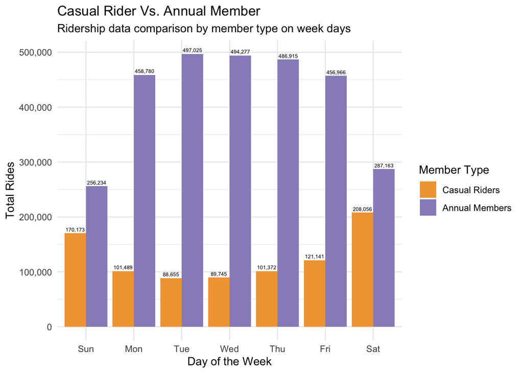

```r
# Let's visualize the number of rides by rider type
viz1 <- all_trips_clean %>% mutate(weekday = wday(started_at, label = TRUE)) %>%
  group_by(member_casual, weekday) %>%
  summarise(total_rides = n(),
            average_duration = mean(ride_length)) %>%
  arrange(member_casual, weekday) %>%
  ggplot(aes(x = weekday, y = total_rides, fill = member_casual)) +
  geom_text(
    aes(label = scales::comma(total_rides)),
    position = position_dodge(width = 0.9),
    vjust = -0.5,
    size = 1.8) +
  scale_y_continuous(labels = scales::comma) +
  scale_fill_manual(
    values = c("Casual" = "#f1a340", "Member" = "#998ec3"),
    breaks = c("Casual", "Member"),  # order of legend values
    labels = c("Casual Riders", "Annual Members")  # new legend value name
  ) +
  geom_col(position = "dodge") +
  theme_minimal() +
  labs(
    title = "Casual Rider Vs. Annual Member",
    subtitle = "Ridership data comparison by member type on week days ",
    x = "Day of the Week",  # Change x-axis label
    y = "Total Rides",     # Change y-axis label
    fill = "Member Type")   # Change legend title
print(viz1)
```

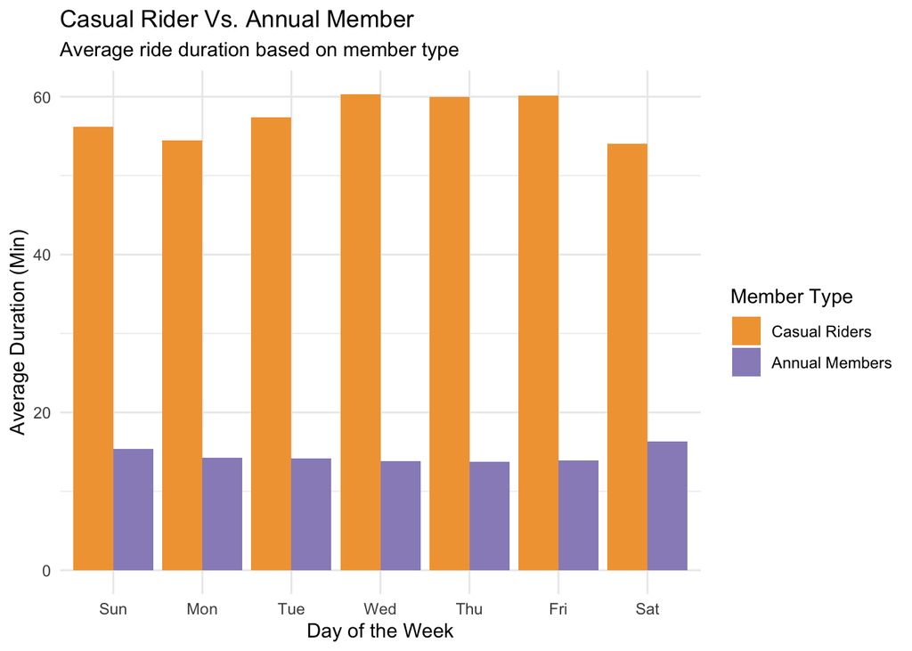

```r
# Let's create a visualization for average duration
viz2 <- all_trips_clean %>% mutate(weekday = wday(started_at, label = TRUE)) %>%
  group_by(member_casual, weekday) %>%
  summarise(total_rides = n(),
            average_duration = mean(ride_length)) %>%
  arrange(member_casual, weekday) %>%
  ggplot(aes(x = weekday, y = average_duration, fill = member_casual)) +
  scale_fill_manual(
    values = c("Casual" = "#f1a340", "Member" = "#998ec3"),
    breaks = c("Casual", "Member"),  # order of legend values
    labels = c("Casual Riders", "Annual Members")  # new legend value name
  ) +
  geom_col(position = "dodge") +
  theme_minimal() +
  labs(
    title = "Casual Rider Vs. Annual Member",
    subtitle = "Average ride duration based on member type",
    x = "Day of the Week",  # Change x-axis label
    y = "Average Duration (Min)",     # Change y-axis label
    fill = "Member Type")   # Change legend title
print(viz2)
```

# Answering business question

## How do annual members and casual riders use Cyclistic bikes differently?

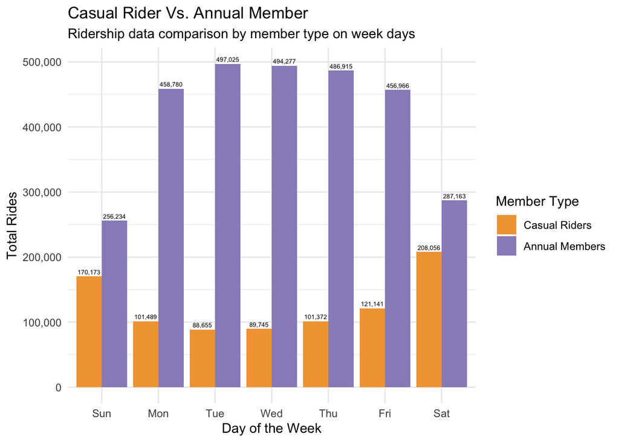

Casual Riders seem to prefer weekends, there total of 208,056 rides in Saturday and 170,173 rides in Sunday. While Annual Member tent to rides on weekdays.

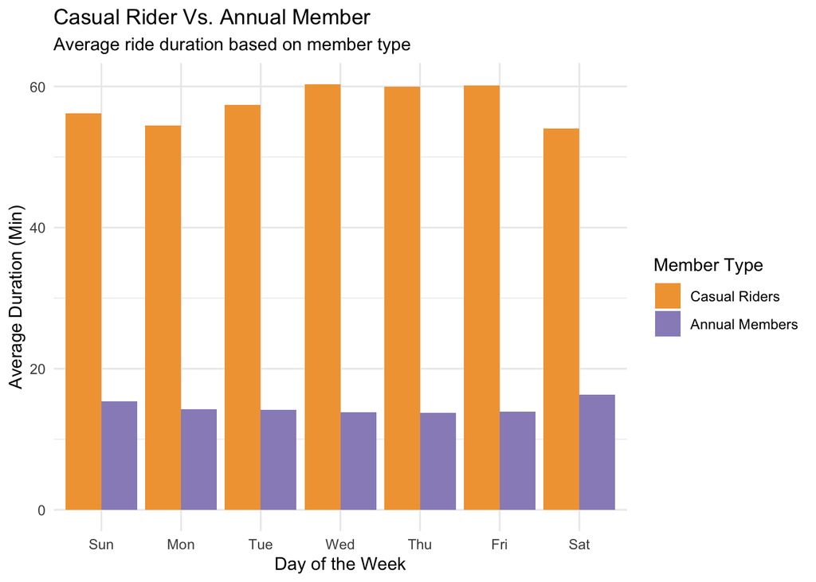

When it comes to average duration, Casual Riders have significantly longer ride duration than Annual Members, with daily rides averaging up to 60 minutes compared to less than 20 minutes for Annual Members.

## Why would casual riders buy Cyclistic annual memberships?

Based on the data Casual Riders are having longer duration than the Annual Member. Since then, it will be more cost-effective for them to purchase an annual membership.

Besides, after they purchases the annual membership they can use bike from any bike station without having to buy single riding ticket every time they want to use the bike.

This could be both cost-effective and time-saving for them in a long run.

## How can Cyclistic use digital media to influence casual riders to become members?

Cyclistic can collaborate with digital influencers who actively use bicycles for commuting or influencers promote sustainable transportation. By colaborating with these influential individuals, Cyclistic can reach a wider audience and raise awareness about their services. These influencers can also serve as potential leads for future marketing campaigns.

# Recommendation based on the analysis

1. Cyclistic can work with digital influencer to reach a wider audience and raise awareness about their service. At the same time as the they reach a wider audience, Cyclistic can give casual riders a discount for their first membership or discount for the casual riders whose ride a certain number in a week.
2. Partnering with local business to offer discount for Casual Riders whose rides bike from Cyclistic to get to the store or maybe co-working space. This would encourage them to consider the annual membership.
3. Adding a point system or free beverages for the Members on a day in a week, this would increase riders to use the bike and persuade the casual rider to switch to annual member for the exclusive product or service.